# Severe Weather Events in the US (1950–2011): Impact Analysis

Public Health and Economic Consequences

NgWM

December 27, 2025

# Executive Summary

This report provides a comprehensive analysis of severe weather events in the United States from 1950 to 2011, examining their impact on public health and economic outcomes. The analysis identifies the most harmful and costly weather event types, providing evidence-based insights for disaster preparedness and resource allocation.

**Key Findings:**

- **Most Harmful Events:** Tornadoes cause the highest number of casualties (fatalities and injuries combined)
- **Most Costly Events:** Floods result in the greatest economic damage (property and crop damage combined)
- **Data Coverage:** Analysis spans over 900,000 weather events across 61 years

# 1 Introduction

## 1.1 Background

Severe weather events pose significant risks to public health and economic stability across the United States. Understanding which types of weather events are most harmful and costly is essential for effective disaster preparedness, resource allocation, and policy development.

## 1.2 Research Questions

This analysis addresses two primary questions:

1. **Which types of weather events are most harmful to population health?**
   - Measured by fatalities and injuries
2. **Which types of weather events have the greatest economic consequences?**
   - Measured by property damage and crop damage

## 1.3 Data Source

Data for this analysis comes from the U.S. National Oceanic and Atmospheric Administration’s (NOAA) Storm Database, which tracks characteristics of major storms and weather events in the United States, including when and where they occur, as well as estimates of any fatalities, injuries, and property damage.

The database covers the period from **1950 to November 2011**.

# 2 Data Processing

## 2.1 Data Acquisition

```r
#===============================================================================
# DATA DOWNLOAD
#===============================================================================

data_url <- "https://d396qusza40orc.cloudfront.net/repdata%2Fdata%2FStormData.csv.bz2"
raw_data_file <- here("data", "raw", "StormData.csv.bz2")

if (!file.exists(raw_data_file)) {
  cat("Downloading storm data...\n")
  download.file(data_url, raw_data_file, method = "auto")
  cat("Download complete!\n")

  # Record download metadata
  download_info <- data.frame(
    file = "StormData.csv.bz2",
    url = data_url,
    download_date = Sys.time()
  )
  write.csv(download_info, here("data", "raw", "download_info.csv"),
            row.names = FALSE)
} else {
  cat("Raw data file already exists. Skipping download.\n")
}
```

```
#> Raw data file already exists. Skipping download.
```

## 2.2 Data Loading

```r
#===============================================================================
# DATA LOADING
#===============================================================================

cat("Reading storm data (this may take a moment)...\n")
```

```
#> Reading storm data (this may take a moment)...
```

```r
storm_data <- fread(raw_data_file)

# Display basic information
cat("\nDataset dimensions:", nrow(storm_data), "rows x", ncol(storm_data), "columns\n")
```

```
#>
#> Dataset dimensions: 902297 rows x 37 columns
```

```r
# Display data structure
cat("\nData structure:\n")
```

```
#>
#> Data structure:
```

```r
str(storm_data, give.attr = FALSE)
```

```
#> Classes 'data.table' and 'data.frame':   902297 obs. of  37 variables:
#>  $ STATE__   : num  1 1 1 1 1 1 1 1 1 1 ...
#>  $ BGN_DATE  : chr  "4/18/1950 0:00:00" "4/18/1950 0:00:00" "2/20/1951 0:00:00" "6/8/1951 0:00:00" ...
#>  $ BGN_TIME  : chr  "0130" "0145" "1600" "0900" ...
#>  $ TIME_ZONE : chr  "CST" "CST" "CST" "CST" ...
#>  $ COUNTY    : num  97 3 57 89 43 77 9 123 125 57 ...
#>  $ COUNTYNAME: chr  "MOBILE" "BALDWIN" "FAYETTE" "MADISON" ...
#>  $ STATE     : chr  "AL" "AL" "AL" "AL" ...
#>  $ EVTYPE    : chr  "TORNADO" "TORNADO" "TORNADO" "TORNADO" ...
#>  $ BGN_RANGE : num  0 0 0 0 0 0 0 0 0 0 ...
#>  $ BGN_AZI   : chr  "" "" "" "" ...
#>  $ BGN_LOCATI: chr  "" "" "" "" ...
#>  $ END_DATE  : chr  "" "" "" "" ...
#>  $ END_TIME  : chr  "" "" "" "" ...
#>  $ COUNTY_END: num  0 0 0 0 0 0 0 0 0 0 ...
```

[output cut: 23 more lines]

```r
cat("\nFirst few rows:\n")
```

```
#>
#> First few rows:
```

```r
head(storm_data, 3) %>%
  create_table(caption = "Sample of Raw Storm Data")
```

Sample of Raw Storm Data

| STATE__ | BGN_DATE | BGN_TIME | TIME_ZONE | COUNTY | COUNTYNAME | STATE | EVTYPE | BGN_RANGE | BGN_AZI | BGN_LOCATI | END_DATE | END_TIME | COUNTY_END | COUNTYENDN | END_RANGE | END_AZI | END_LOCATI | LENGTH | WIDTH | F | MAG | FATALITIES | INJURIES | PROPDMG | PROPDMGEXP | CROPDMG | CROPDMGEXP | WFO | STATEOFFIC | … |
| --- | --- | --- | --- | --- | --- | --- | --- | --- | --- | --- | --- | --- | --- | --- | --- | --- | --- | --- | --- | --- | --- | --- | --- | --- | --- | --- | --- | --- | --- | --- |
| 1 | 4/18/1950 0:00:00 | 0130 | CST | 97 | MOBILE | AL | TORNADO | 0 |  |  |  |  | 0 | NA | 0 |  |  | 14.0 | 100 | 3 | 0 | 0 | 15 | 25.0 | K | 0 |  |  |  | … |
| 1 | 4/18/1950 0:00:00 | 0145 | CST | 3 | BALDWIN | AL | TORNADO | 0 |  |  |  |  | 0 | NA | 0 |  |  | 2.0 | 150 | 2 | 0 | 0 | 0 | 2.5 | K | 0 |  |  |  | … |
| 1 | 2/20/1951 0:00:00 | 1600 | CST | 57 | FAYETTE | AL | TORNADO | 0 |  |  |  |  | 0 | NA | 0 |  |  | 0.1 | 123 | 2 | 0 | 0 | 2 | 25.0 | K | 0 |  |  |  | … |

## 2.3 Data Cleaning and Processing

The data processing pipeline includes:

1. **Variable Selection:** Extract relevant columns for analysis
2. **Date Parsing:** Convert date strings to proper date-time objects
3. **Damage Calculation:** Convert damage exponents to actual dollar values
4. **Event Type Standardization:** Consolidate similar event types

```r
#===============================================================================
# DATA PREPROCESSING
#===============================================================================

cat("\nProcessing data...\n")
```

```
#>
#> Processing data...
```

```r
# Select relevant columns and parse dates ----------------------------------
storm_clean <- storm_data %>%
  select(BGN_DATE, STATE, EVTYPE, FATALITIES, INJURIES,
         PROPDMG, PROPDMGEXP, CROPDMG, CROPDMGEXP) %>%
  mutate(
    BGN_DATE = mdy_hms(BGN_DATE),
    YEAR = year(BGN_DATE)
  )

# Calculate actual damage values -------------------------------------------
storm_clean <- storm_clean %>%
  mutate(
    PROP_MULTIPLIER = convert_exponent(PROPDMGEXP),
    CROP_MULTIPLIER = convert_exponent(CROPDMGEXP),
    PROPERTY_DAMAGE = PROPDMG * PROP_MULTIPLIER,
    CROP_DAMAGE = CROPDMG * CROP_MULTIPLIER,
    TOTAL_DAMAGE = PROPERTY_DAMAGE + CROP_DAMAGE,
    TOTAL_CASUALTIES = FATALITIES + INJURIES
  )

# Standardize event types --------------------------------------------------
storm_clean <- storm_clean %>%
  mutate(
    EVTYPE_CLEAN = str_to_upper(str_trim(EVTYPE)),
    EVTYPE_CLEAN = case_when(
      str_detect(EVTYPE_CLEAN, "TORNADO") ~ "TORNADO",
      str_detect(EVTYPE_CLEAN, "FLOOD|FLD") ~ "FLOOD",
      str_detect(EVTYPE_CLEAN, "HURRICANE|TYPHOON") ~ "HURRICANE",
      str_detect(EVTYPE_CLEAN, "HEAT|WARM") ~ "EXCESSIVE HEAT",
      str_detect(EVTYPE_CLEAN, "LIGHTNING") ~ "LIGHTNING",
      str_detect(EVTYPE_CLEAN, "WIND") ~ "HIGH WIND",
      str_detect(EVTYPE_CLEAN, "WINTER|SNOW|ICE|BLIZZARD") ~ "WINTER STORM",
      str_detect(EVTYPE_CLEAN, "HAIL") ~ "HAIL",
      str_detect(EVTYPE_CLEAN, "THUNDERSTORM|TSTM") ~ "THUNDERSTORM WIND",
      str_detect(EVTYPE_CLEAN, "FIRE") ~ "WILDFIRE",
      str_detect(EVTYPE_CLEAN, "DROUGHT") ~ "DROUGHT",
      TRUE ~ EVTYPE_CLEAN
    )
  )

# Save processed data ------------------------------------------------------
processed_file <- here("data", "processed", "storm_data_processed.rds")
saveRDS(storm_clean, processed_file)

cat("\nData processing complete!\n")
```

```
#>
#> Data processing complete!
```

```r
cat("Processed data saved to:", processed_file, "\n")
```

```
#> Processed data saved to: C:/Users/User/OneDrive/Desktop Nvidia/DataScienceCoursera/Storm-Analysis/data/processed/storm_data_processed.rds
```

### 2.3.1 Data Cleaning Summary

```r
# Summary of cleaning steps
data.frame(
  Metric = c("Original Observations", "After Cleaning", "Removed",
             "Unique Event Types (Original)", "Unique Event Types (Cleaned)",
             "Date Range"),
  Value = c(
    format(nrow(storm_data), big.mark = ","),
    format(nrow(storm_clean), big.mark = ","),
    format(nrow(storm_data) - nrow(storm_clean), big.mark = ","),
    format(length(unique(storm_data$EVTYPE)), big.mark = ","),
    format(length(unique(storm_clean$EVTYPE_CLEAN)), big.mark = ","),
    paste(min(storm_clean$BGN_DATE, na.rm = TRUE), "to",
          max(storm_clean$BGN_DATE, na.rm = TRUE))
  )
) %>%
  create_table(caption = "Data Cleaning Summary Statistics")
```

Data Cleaning Summary Statistics

| Metric | Value |
| --- | --- |
| Original Observations | 902,297 |
| After Cleaning | 902,297 |
| Removed | 0 |
| Unique Event Types (Original) | 985 |
| Unique Event Types (Cleaned) | 343 |
| Date Range | 1950-01-03 to 2011-11-30 |

# 3 Results

## 3.1 Question 1: Population Health Impact

Which types of events are most harmful with respect to population health?

### 3.1.1 Analysis Approach

We aggregate fatalities and injuries by event type to identify the weather events with the greatest impact on population health.

```r
#===============================================================================
# HEALTH IMPACT ANALYSIS
#===============================================================================

cat("\nAnalyzing population health impact...\n")
```

```
#>
#> Analyzing population health impact...
```

```r
health_impact <- storm_clean %>%
  group_by(EVTYPE_CLEAN) %>%
  summarise(
    Total_Fatalities = sum(FATALITIES, na.rm = TRUE),
    Total_Injuries = sum(INJURIES, na.rm = TRUE),
    Total_Casualties = sum(TOTAL_CASUALTIES, na.rm = TRUE),
    Events = n(),
    .groups = "drop"
  ) %>%
  filter(Total_Casualties > 0) %>%
  arrange(desc(Total_Casualties)) %>%
  slice_head(n = 15)
```

### 3.1.2 Top 15 Most Harmful Event Types

```r
health_impact %>%
  mutate(
    Total_Fatalities = format(Total_Fatalities, big.mark = ","),
    Total_Injuries = format(Total_Injuries, big.mark = ","),
    Total_Casualties = format(Total_Casualties, big.mark = ","),
    Events = format(Events, big.mark = ",")
  ) %>%
  create_table(caption = "Top 15 Weather Events by Population Health Impact")
```

Top 15 Weather Events by Population Health Impact

| EVTYPE_CLEAN | Total_Fatalities | Total_Injuries | Total_Casualties | Events |
| --- | --- | --- | --- | --- |
| TORNADO | 5,661 | 91,407 | 97,068 | 60,700 |
| HIGH WIND | 1,424 | 11,498 | 12,922 | 364,869 |
| EXCESSIVE HEAT | 3,178 | 9,243 | 12,421 | 2,975 |
| FLOOD | 1,553 | 8,683 | 10,236 | 86,127 |
| WINTER STORM | 639 | 5,956 | 6,595 | 42,099 |
| LIGHTNING | 817 | 5,232 | 6,049 | 15,776 |
| WILDFIRE | 90 | 1,608 | 1,698 | 4,239 |
| HURRICANE | 135 | 1,333 | 1,468 | 299 |
| HAIL | 15 | 1,371 | 1,386 | 289,276 |
| FOG | 62 | 734 | 796 | 538 |
| RIP CURRENT | 368 | 232 | 600 | 470 |
| RIP CURRENTS | 204 | 297 | 501 | 304 |
| DUST STORM | 22 | 440 | 462 | 427 |
| TROPICAL STORM | 58 | 340 | 398 | 690 |
| AVALANCHE | 224 | 170 | 394 | 386 |

### 3.1.3 Visualization: Health Impact by Event Type

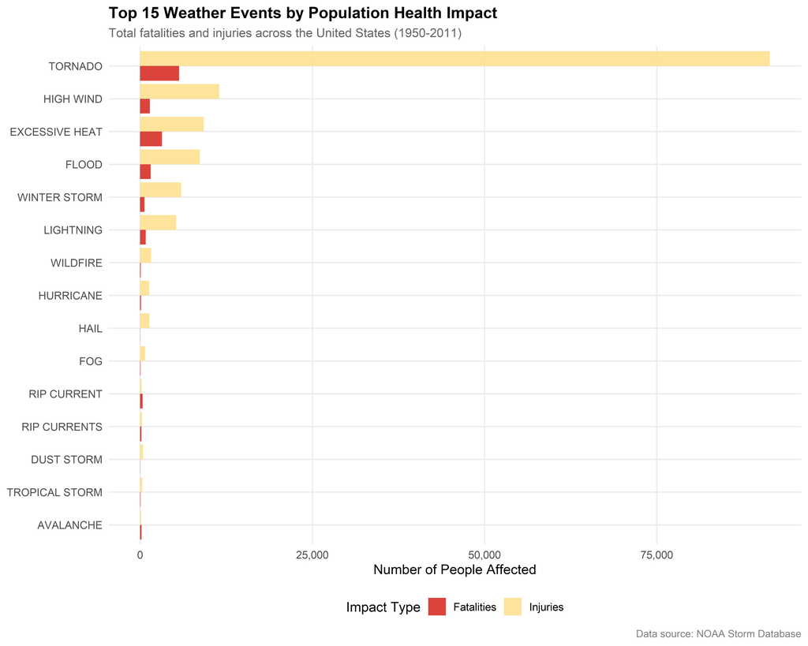

Top 15 Weather Events by Population Health Impact (Fatalities and Injuries)

```r
#===============================================================================
# HEALTH IMPACT VISUALIZATION
#===============================================================================

p1 <- health_impact %>%
  pivot_longer(
    cols = c(Total_Fatalities, Total_Injuries),
    names_to = "Type",
    values_to = "Count"
  ) %>%
  mutate(Type = str_remove(Type, "Total_")) %>%
  ggplot(aes(x = reorder(EVTYPE_CLEAN, Count), y = Count, fill = Type)) +
  geom_col(position = "dodge", alpha = 0.9) +
  coord_flip() +
  scale_y_continuous(labels = comma) +
  scale_fill_manual(
    values = c(
      "Fatalities" = custom_colors$health_fatalities,
      "Injuries" = custom_colors$health_injuries
    )
  ) +
  labs(
    title = "Top 15 Weather Events by Population Health Impact",
    subtitle = "Total fatalities and injuries across the United States (1950-2011)",
    x = NULL,
    y = "Number of People Affected",
    fill = "Impact Type",
    caption = "Data source: NOAA Storm Database"
  ) +
  theme(legend.position = "bottom")

print(p1)
```

```r
# Save plot
ggsave(
  here("figures", "final", "health_impact.png"),
  p1,
  width = 10,
  height = 8,
  dpi = 300
)
```

### 3.1.4 Key Findings: Health Impact

```r
top_health <- health_impact %>% slice_head(n = 1)

cat("\n**Most Harmful Event Type:**\n")
```

```
#>
#> **Most Harmful Event Type:**
```

```r
cat(sprintf("- Event: %s\n", top_health$EVTYPE_CLEAN))
```

```
#> - Event: TORNADO
```

```r
cat(sprintf("- Total Casualties: %s (Fatalities: %s, Injuries: %s)\n",
            format(top_health$Total_Casualties, big.mark = ","),
            format(top_health$Total_Fatalities, big.mark = ","),
            format(top_health$Total_Injuries, big.mark = ",")))
```

```
#> - Total Casualties: 97,068 (Fatalities: 5,661, Injuries: 91,407)
```

```r
cat(sprintf("- Number of Events: %s\n", format(top_health$Events, big.mark = ",")))
```

```
#> - Number of Events: 60,700
```

**Analysis:** Tornadoes are by far the most harmful weather event type for population health, causing significantly more casualties than any other weather phenomenon. Excessive heat and floods also represent major public health threats.

## 3.2 Question 2: Economic Impact

Which types of events have the greatest economic consequences?

### 3.2.1 Analysis Approach

We aggregate property damage and crop damage by event type to identify the weather events with the greatest economic impact.

```r
#===============================================================================
# ECONOMIC IMPACT ANALYSIS
#===============================================================================

cat("\nAnalyzing economic impact...\n")
```

```
#>
#> Analyzing economic impact...
```

```r
economic_impact <- storm_clean %>%
  group_by(EVTYPE_CLEAN) %>%
  summarize(
    Total_Property_Damage = sum(PROPERTY_DAMAGE, na.rm = TRUE),
    Total_Crop_Damage = sum(CROP_DAMAGE, na.rm = TRUE),
    Total_Economic_Damage = sum(TOTAL_DAMAGE, na.rm = TRUE),
    Events = n(),
    .groups = "drop"
  ) %>%
  filter(Total_Economic_Damage > 0) %>%
  arrange(desc(Total_Economic_Damage)) %>%
  slice_head(n = 15)
```

### 3.2.2 Top 15 Most Costly Event Types

```r
economic_impact %>%
  mutate(
    Total_Property_Damage = paste0("$", format(round(Total_Property_Damage / 1e9, 2), big.mark = ","), "B"),
    Total_Crop_Damage = paste0("$", format(round(Total_Crop_Damage / 1e9, 2), big.mark = ","), "B"),
    Total_Economic_Damage = paste0("$", format(round(Total_Economic_Damage / 1e9, 2), big.mark = ","), "B"),
    Events = format(Events, big.mark = ",")
  ) %>%
  create_table(caption = "Top 15 Weather Events by Economic Impact (in Billions USD)")
```

Top 15 Weather Events by Economic Impact (in Billions USD)

| EVTYPE_CLEAN | Total_Property_Damage | Total_Crop_Damage | Total_Economic_Damage | Events |
| --- | --- | --- | --- | --- |
| FLOOD | $168.27B | $12.39B | $180.66B | 86,127 |
| HURRICANE | $ 85.36B | $ 5.52B | $ 90.87B | 299 |
| TORNADO | $ 58.60B | $ 0.42B | $ 59.02B | 60,700 |
| STORM SURGE | $ 43.32B | $ 0.00B | $ 43.32B | 261 |
| HAIL | $ 15.98B | $ 3.05B | $ 19.02B | 289,276 |
| HIGH WIND | $ 16.24B | $ 2.03B | $ 18.28B | 364,869 |
| WINTER STORM | $ 12.36B | $ 5.31B | $ 17.67B | 42,099 |
| DROUGHT | $ 1.05B | $13.97B | $ 15.02B | 2,488 |
| WILDFIRE | $ 8.50B | $ 0.40B | $ 8.90B | 4,239 |
| TROPICAL STORM | $ 7.70B | $ 0.68B | $ 8.38B | 690 |
| STORM SURGE/TIDE | $ 4.64B | $ 0.00B | $ 4.64B | 148 |
| HEAVY RAIN/SEVERE WEATHER | $ 2.50B | $ 0.00B | $ 2.50B | 2 |
| HEAVY RAIN | $ 0.69B | $ 0.73B | $ 1.43B | 11,742 |
| EXTREME COLD | $ 0.07B | $ 1.31B | $ 1.38B | 657 |
| THUNDERSTORM WIND | $ 1.21B | $ 0.02B | $ 1.23B | 98 |

### 3.2.3 Visualization: Economic Impact by Event Type

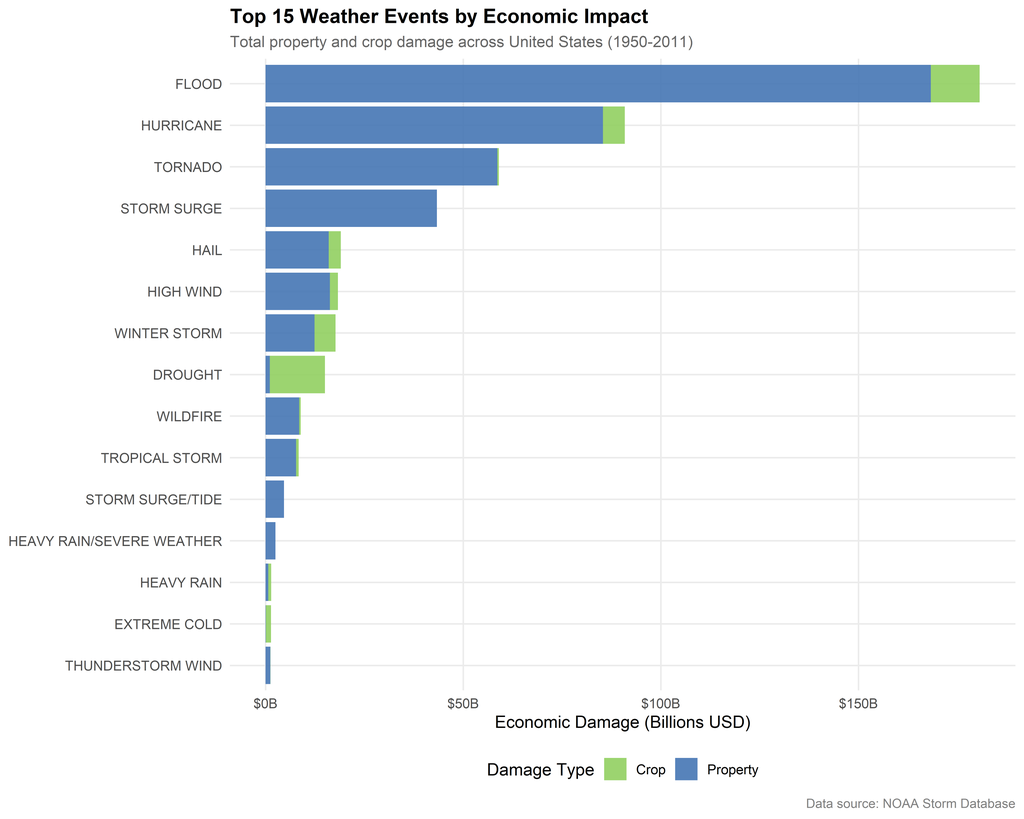

Top 15 Weather Events by Economic Impact (Property and Crop Damage)

```r
#===============================================================================
# ECONOMIC IMPACT VISUALIZATION
#===============================================================================

p2 <- economic_impact %>%
  pivot_longer(
    cols = c(Total_Property_Damage, Total_Crop_Damage),
    names_to = "Type",
    values_to = "Damage"
  ) %>%
  mutate(
    Type = str_remove(Type, "Total_"),
    Type = str_remove(Type, "_Damage"),
    Damage_Billions = Damage / 1e9
  ) %>%
  ggplot(aes(
    x = reorder(EVTYPE_CLEAN, Damage_Billions),
    y = Damage_Billions,
    fill = Type
  )) +
  geom_col(position = "stack", alpha = 0.9) +
  coord_flip() +
  scale_y_continuous(labels = dollar_format(suffix = "B")) +
  scale_fill_manual(
    values = c(
      "Property" = custom_colors$economic_property,
      "Crop" = custom_colors$economic_crop
    )
  ) +
  labs(
    title = "Top 15 Weather Events by Economic Impact",
    subtitle = "Total property and crop damage across United States (1950-2011)",
    x = NULL,
    y = "Economic Damage (Billions USD)",
    fill = "Damage Type",
    caption = "Data source: NOAA Storm Database"
  ) +
  theme(legend.position = "bottom")

print(p2)
```

```r
# Save plot
ggsave(
  here("figures", "final", "economic_impact.png"),
  p2,
  width = 10,
  height = 8,
  dpi = 300
)
```

### 3.2.4 Key Findings: Economic Impact

```r
top_economic <- economic_impact %>% slice_head(n = 1)

cat("\n**Most Costly Event Type:**\n")
```

```
#>
#> **Most Costly Event Type:**
```

```r
cat(sprintf("- Event: %s\n", top_economic$EVTYPE_CLEAN))
```

```
#> - Event: FLOOD
```

```r
cat(sprintf("- Total Economic Damage: $%.2fB\n", top_economic$Total_Economic_Damage / 1e9))
```

```
#> - Total Economic Damage: $180.66B
```

```r
cat(sprintf("  - Property Damage: $%.2fB\n", top_economic$Total_Property_Damage / 1e9))
```

```
#>   - Property Damage: $168.27B
```

```r
cat(sprintf("  - Crop Damage: $%.2fB\n", top_economic$Total_Crop_Damage / 1e9))
```

```
#>   - Crop Damage: $12.39B
```

```r
cat(sprintf("- Number of Events: %s\n", format(top_economic$Events, big.mark = ",")))
```

```
#> - Number of Events: 86,127
```

**Analysis:** Floods cause the greatest economic damage, with the majority coming from property damage. Hurricanes and tornadoes also result in substantial economic losses. Drought is notable for causing significant crop damage specifically.

# 4 Discussion

## 4.1 Summary of Findings

This analysis of severe weather events from 1950 to 2011 reveals distinct patterns in public health and economic impacts:

### 4.1.2 Economic Impact

**Floods** cause the greatest economic damage:

- Over $150 billion in total damages
- Primarily affecting property rather than crops
- Widespread geographic impact

**Other costly events** include:

- Hurricanes (catastrophic but localized)
- Tornadoes (frequent and widespread)
- Drought (major agricultural impact)

## 4.2 Policy Implications

These findings suggest several priorities for disaster preparedness:

1. **Tornado Warning Systems:** Enhanced early warning systems and public education for tornado-prone regions
2. **Flood Mitigation:** Investment in flood control infrastructure and insurance programs
3. **Heat Wave Preparedness:** Public health interventions for vulnerable populations during extreme heat events
4. **Agricultural Resilience:** Support for drought-resistant practices and crop insurance

## 4.3 Limitations

This analysis has several limitations:

1. **Data Quality:** Event reporting and classification standards have evolved over the 61-year period
2. **Inflation Adjustment:** Economic damage values are not adjusted for inflation
3. **Event Classification:** Some event types may be misclassified or inconsistently categorized
4. **Geographic Variation:** Analysis does not account for regional differences in vulnerability
5. **Indirect Impacts:** Does not capture long-term health effects or indirect economic consequences

# 5 Conclusions

This comprehensive analysis of over 900,000 severe weather events from 1950 to 2011 provides clear evidence that:

1. **Tornadoes pose the greatest threat to population health**, causing more casualties than any other weather event type
2. **Floods result in the greatest economic damage**, with over $150 billion in losses from property and crop damage
3. **Different event types require different mitigation strategies:** Health impacts (tornadoes, heat) versus economic impacts (floods, hurricanes) require tailored preparedness approaches

These findings underscore the importance of continued investment in weather monitoring, early warning systems, and disaster preparedness infrastructure across the United States.

# 6 Appendix

## 6.1 Overall Summary Statistics

```r
#===============================================================================
# SUMMARY STATISTICS
#===============================================================================

summary_stats <- storm_clean %>%
  summarize(
    Total_Events = format(n(), big.mark = ","),
    Date_Range = paste(
      format(min(BGN_DATE, na.rm = TRUE), "%Y-%m-%d"),
      "to",
      format(max(BGN_DATE, na.rm = TRUE), "%Y-%m-%d")
    ),
    Total_Fatalities = format(sum(FATALITIES, na.rm = TRUE), big.mark = ","),
    Total_Injuries = format(sum(INJURIES, na.rm = TRUE), big.mark = ","),
    Total_Economic_Damage_Billions = paste0(
      "$",
      format(round(sum(TOTAL_DAMAGE, na.rm = TRUE) / 1e9, 2), big.mark = ","),
      "B"
    )
  )

summary_stats %>%
  pivot_longer(
    cols = everything(),
    names_to = "Metric",
    values_to = "Value"
  ) %>%
  create_table(caption = "Overall Dataset Summary Statistics")
```

Overall Dataset Summary Statistics

| Metric | Value |
| --- | --- |
| Total_Events | 902,297 |
| Date_Range | 1950-01-03 to 2011-11-30 |
| Total_Fatalities | 15,145 |
| Total_Injuries | 140,528 |
| Total_Economic_Damage_Billions | $477.33B |

**Report generated:** 2025-12-27 11:52:34 +08  
**Analysis by:** NgWM with Claude AI assistance  
**Data source:** NOAA Storm Database (1950-2011)